# Viewsheds and Shortest Path

WS 2016/17

## Prerequisites

## setwd, library, data, cleaning

```r
setwd("YOUR-PATH")
```

```r
raw_data <- read.table(file = "data/FS_UTM.csv",
                       header = TRUE,
                       sep = ";",
                       stringsAsFactors = FALSE,
                       quote = "")

## check for issues/problems
## str(raw_data)
## apply(X=raw_data[,4:20], MARGIN = 2, FUN=function(x){x[x>1]})
raw_data$settlement[raw_data$settlement > 1] <- 1

library(sp)
sites <- raw_data[(raw_data$settlement == 1 & raw_data$iron.age == 1),]
coordinates(sites) <- ~xUTM+yUTM
proj4string(sites) <- CRS("+init=epsg:32634")
```

## Viewshed Analysis using R and GRASS GIS

## Initialize GRASS

Be aware, for the following to work you need to have GRASS GIS installed on your system.

Load library, initialize the GRASS environment with default values (everything is stored as temporary files; you can change this if you want to come back to earlier stages of your work)

```r
library(rgrass7)
```

```r
loc <-  initGRASS(gisBase = "/usr/lib/grass72/", home=tempdir() ,mapset = "PERMANENT", override = TRUE)
execGRASS("g.proj", flags = c("c"), parameters = list(proj4="+init=epsg:32634"))
```

```
## Default region was updated to the new projection, but if you have multiple
## mapsets `g.region -d` should be run in each to update the region from the
## default
## Projection information updated
```

## Load SRTM into GRASS

```r
library(rgdal)
srtm <- readGDAL("results/srtm.tif")
```

```
## results/srtm.tif has GDAL driver GTiff
## and has 1705 rows and 3036 columns
```

```r
library(raster)
srtm <- aggregate(raster(srtm), fact = 10)
library(maptools)
srtm <- as(object = srtm, Class = "SpatialGridDataFrame")
```

```r
writeRAST(x = srtm,
          vname="dem",
          flags = c("overwrite")
          )
```

```
##    0%   3%   6%   9%  12%  15%  18%  21%  24%  27%  30%  33%  36%  39%  42%  45%  48%  51%  54%  57%  60%  63%  66%  69%  72%  75%  78%  81%  84%  87%  90%  93%  96%  99% 100%
```

## Load SRTM into GRASS

Now, we need to adjust the region's resolution

```r
execGRASS("g.region",
          parameters = list(raster = "dem",
                            res = as.character(srtm@grid@cellsize[1])
                            )
          )
```

## Check Region characteristics

```r
execGRASS("g.region", flags = c("p"))
```

```
## projection: 1 (UTM)
## zone:       34
## datum:      wgs84
## ellipsoid:  wgs84
## north:      5155478.7961
## south:      5001578.7961
## west:       433121.3283
## east:       706721.3283
## nsres:      900
## ewres:      900
## rows:       171
## cols:       304
## cells:      51984
```

## Viewshed in GRASS

Now we are ready to perform our viewshed analysis. First, display the possible commands of the respetive GRASS GIS module

```r
parseGRASS("r.viewshed")
```

```
## Command: r.viewshed
## Description: Computes the viewshed of a point on an elevation raster map.
## Keywords: Default format: NULL (invisible), vertical angle wrt viewpoint (visible).
## Parameters:
##   name: input, type: string, required: yes, multiple: no
##   keydesc: name, keydesc_count: 1
## [Name of input elevation raster map]
##   name: output, type: string, required: yes, multiple: no
##   keydesc: name, keydesc_count: 1
## [Name for output raster map]
##   name: coordinates, type: float, required: yes, multiple: no
##   keydesc: east,north, keydesc_count: 2
## [Coordinates of viewing position]
##   name: observer_elevation, type: float, required: no, multiple: no
##   default: 1.75
##   keydesc: value, keydesc_count: 1
## [Viewing elevation above the ground]
##   name: target_elevation, type: float, required: no, multiple: no
##   default: 0.0
##   keydesc: value, keydesc_count: 1
## [Offset for target elevation above the ground]
##   name: max_distance, type: float, required: no, multiple: no
##   default: -1
##   keydesc: value, keydesc_count: 1
## [Maximum visibility radius. By default infinity (-1)]
##   name: refraction_coeff, type: float, required: no, multiple: no
##   default: 0.14286
## [Refraction coefficient]
##   name: memory, type: integer, required: no, multiple: no
##   default: 500
##   keydesc: value, keydesc_count: 1
## [Amount of memory to use in MB]
##   name: directory, type: string, required: no, multiple: no
## [Directory to hold temporary files (they can be large)]
## Flags:
##   name: c [Consider the curvature of the earth (current ellipsoid)] {FALSE}
##   name: r [Consider the effect of atmospheric refraction] {FALSE}
##   name: b [Output format is invisible = 0, visible = 1] {FALSE}
##   name: e [Output format is invisible = NULL, else current elev - viewpoint_elev] {FALSE}
##   name: overwrite [Allow output files to overwrite existing files] {FALSE}
##   name: help [Print usage summary] {FALSE}
##   name: verbose [Verbose module output] {FALSE}
##   name: quiet [Quiet module output] {FALSE}
```

## Viewshed in GRASS - for one point

```r
execGRASS("r.viewshed", flags = c("overwrite","b"),
          parameters = list(input = "dem",
                            output = "viewshed.single",
                            coordinates = sites@coords[1,]
          )
)
```

```
## Computing events...
##    0%   3%   6%   9%  12%  15%  18%  21%  24%  27%  30%  33%  36%  39%  42%  45%  48%  51%  54%  57%  60%  63%  66%  69%  72%  75%  78%  81%  84%  87%  90%  93%  96%  99% 100%
## Computing visibility...
##    0%   2%   4%   6%   8%  10%  12%  14%  16%  18%  20%  22%  24%  26%  28%  30%  32%  34%  36%  38%  40%  42%  44%  46%  48%  50%  52%  54%  56%  58%  60%  62%  64%  66%  68%  70%  72%  74%  76%  78%  80%  82%  84%  86%  88%  90%  92%  94%  96%  98% 100%
## Writing output raster map...
##    0%   6%  12%  18%  24%  30%  36%  42%  48%  54%  60%  66%  72%  78%  84%  90%  96% 100%
```

```r
single.viewshed <- readRAST("viewshed.single")
```

```
## Creating BIL support files...
## Exporting raster as integer values (bytes=4)
##    0%   3%   6%   9%  12%  15%  18%  21%  24%  27%  30%  33%  36%  39%  42%  45%  48%  51%  54%  57%  60%  63%  66%  69%  72%  75%  78%  81%  84%  87%  90%  93%  96%  99% 100%
```

## Viewshed in GRASS - for one point

What might be wrong with this result?

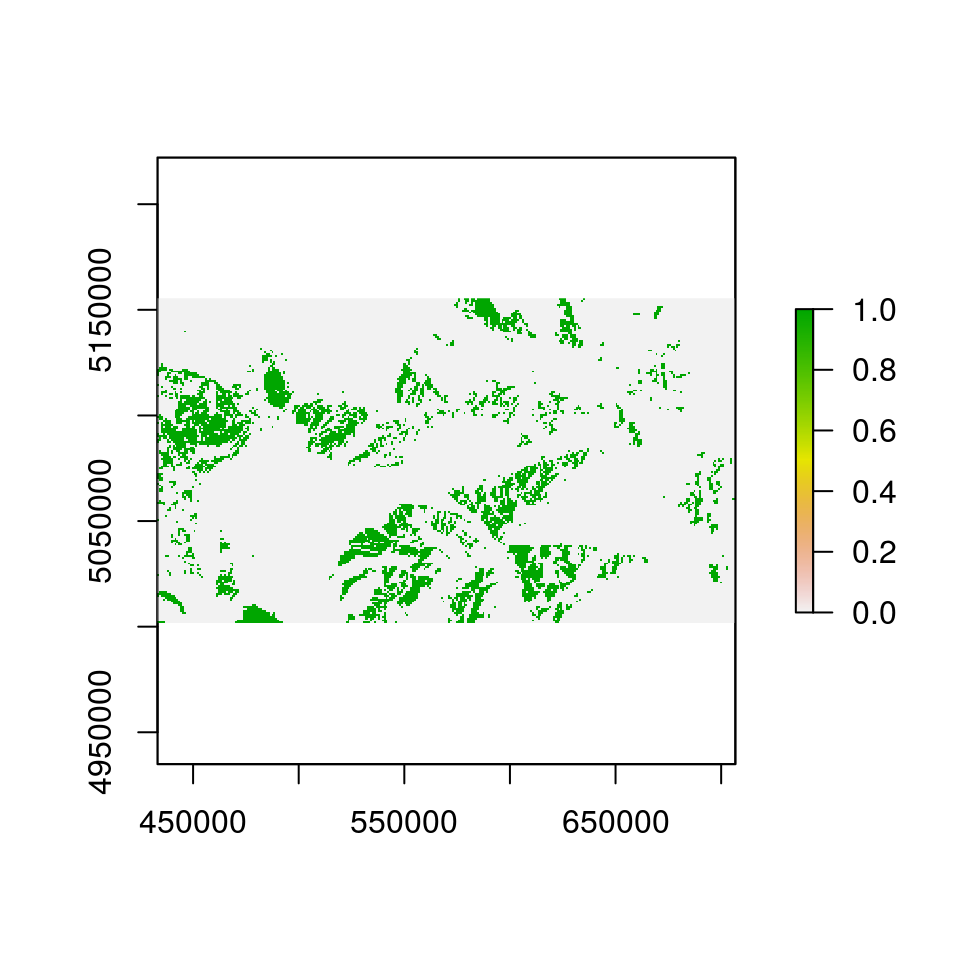

```r
library(raster)
plot(raster(single.viewshed))
points(sites@coords[2,], pch = 19)
```

## Viewshed in GRASS - for one point

```r
execGRASS("r.viewshed", flags = c("overwrite","b"),
          parameters = list(input = "dem",
                            output = "viewshed.single",
                            coordinates = sites@coords[1,],
                            max_distance=50000

          )
)
```

```
## Computing events...
##    0%   3%   6%   9%  12%  15%  18%  21%  24%  27%  30%  33%  36%  39%  42%  45%  48%  51%  54%  57%  60%  63%  66%  69%  72%  75%  78%  81%  84%  87%  90%  93%  96%  99% 100%
## Computing visibility...
##    0%   2%   4%   6%   8%  10%  12%  14%  16%  18%  20%  22%  24%  26%  28%  30%  32%  34%  36%  38%  40%  42%  44%  46%  48%  50%  52%  54%  56%  58%  60%  62%  64%  66%  68%  70%  72%  74%  76%  78%  80%  82%  84%  86%  88%  90%  92%  94%  96%  98% 100%
## Writing output raster map...
##    0%   6%  12%  18%  24%  30%  36%  42%  48%  54%  60%  66%  72%  78%  84%  90%  96% 100%
```

```r
single.viewshed <- readRAST("viewshed.single")
```

```
## Creating BIL support files...
## Exporting raster as integer values (bytes=4)
##    0%   3%   6%   9%  12%  15%  18%  21%  24%  27%  30%  33%  36%  39%  42%  45%  48%  51%  54%  57%  60%  63%  66%  69%  72%  75%  78%  81%  84%  87%  90%  93%  96%  99% 100%
```

## Viewshed in GRASS - for one point

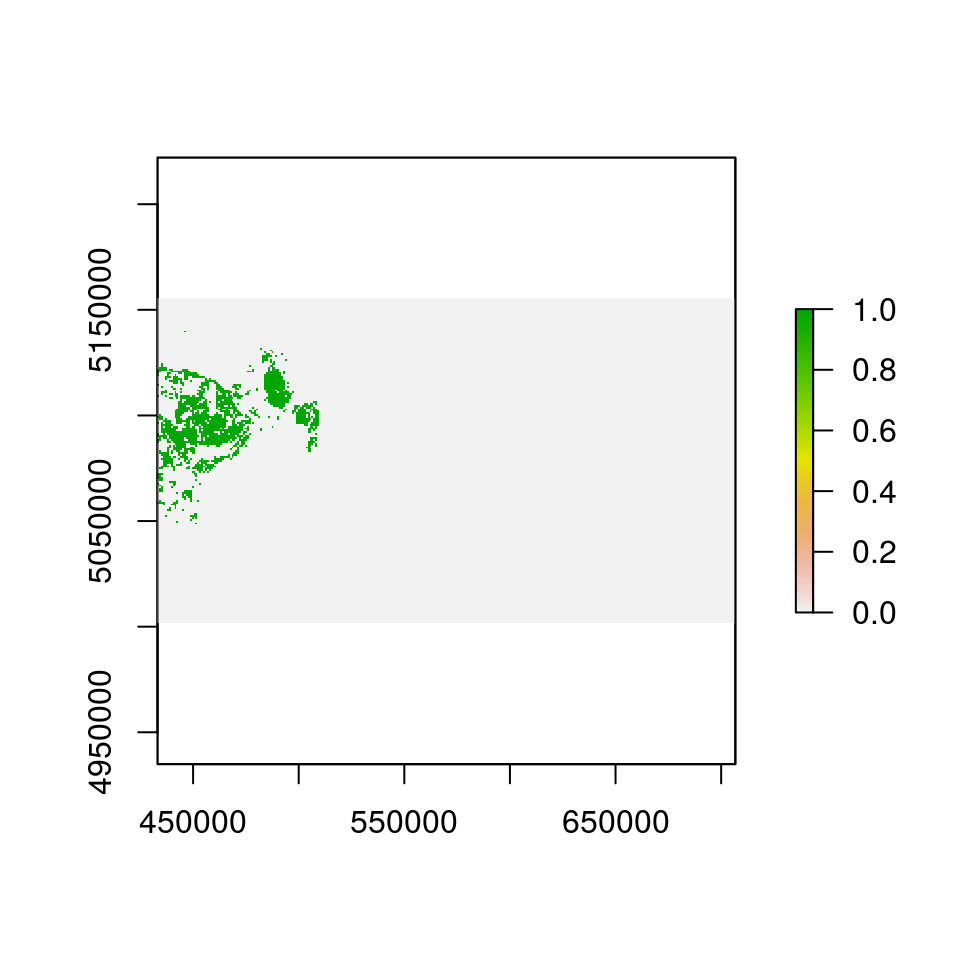

```r
plot(raster(single.viewshed))
points(sites@coords[1,])
```

## Viewshed in GRASS - all points

Again a loop.

Procedure:

- for all points
- take i-th coordinate
- calculate viewshed
- save result in raster brick
- optional: plot progress information

## Viewshed in GRASS - all points

```r
view <- srtm
view@data$band1 <- 0

writeRAST(x = view,
          vname="view",
          flags = c("overwrite")
          )
```

```
##    0%   3%   6%   9%  12%  15%  18%  21%  24%  27%  30%  33%  36%  39%  42%  45%  48%  51%  54%  57%  60%  63%  66%  69%  72%  75%  78%  81%  84%  87%  90%  93%  96%  99% 100%
```

```r
for (i in seq(1, length(sites@coords[,1]))) {
    execGRASS("r.viewshed",
              flags = c("overwrite","b", "quiet"),
              parameters = list(input = "dem",
                                output = "view_tmp",
                                coordinates = sites@coords[i,],
                                max_distance = 40000,
                                memory = 1000)
              )
    execGRASS("r.mapcalc",
              parameters = list(expression = paste0("'view' = 'view' + view_tmp")
                                ),
              flags = c("overwrite", "quiet")
              )
    #cat("iteration ", i, " of ", length(sites@coords[,1]),"\n")
}

view <- readRAST("view")
```

```
## Creating BIL support files...
## Exporting raster as floating values (bytes=8)
##    0%   3%   6%   9%  12%  15%  18%  21%  24%  27%  30%  33%  36%  39%  42%  45%  48%  51%  54%  57%  60%  63%  66%  69%  72%  75%  78%  81%  84%  87%  90%  93%  96%  99% 100%
```

## Viewshed in GRASS - all points

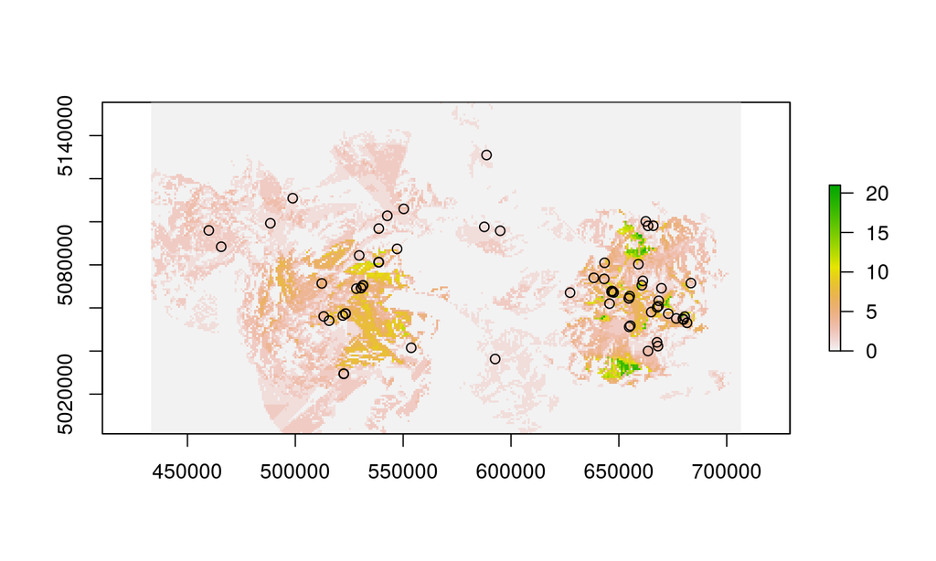

```r
plot(raster(view))
points(sites)
```

## Shortest Path

## Euclidean Distance

The Euclidean distance between points i and j is the length of the line segment connecting them.

\[ \begin{aligned} d(i,j) = \sqrt{(x_i-x_j)^2 + (y_i-y_j)^2} \end{aligned} \]

Manual calculation:

```r
sqrt((sites@coords[1,1]-sites@coords[2,1])^2 + (sites@coords[1,2]-sites@coords[2,2])^2)
```

```
## [1] 41668.6
```

## Euclidean Distance

The Euclidean distance between points i and j is the length of the line segment connecting them.

\[ \begin{aligned} d(i,j) = \sqrt{(x_i-x_j)^2 + (y_i-y_j)^2} \end{aligned} \]

With own function:

```r
e.d <- function(x, y) {
    sqrt(sum((x[1] - y[1])^2 + (x[2] - y[2])^2))
}
e.d(sites@coords[1,],sites@coords[2,])
```

```
## [1] 41668.6
```

## Euclidean Distance

The Euclidean distance between points i and j is the length of the line segment connecting them.

\[ \begin{aligned} d(i,j) = \sqrt{(x_i-x_j)^2 + (y_i-y_j)^2} \end{aligned} \]

With own function - for all connections:

```r
x_comb <- combn(x = sites@coords[,1],
                m = 2)
y_comb <- combn(x = sites@coords[,2],
                m = 2)

ed_sites <- c()
for (i in 1:length(x_comb)/2) {
    ed_sites[i] <- e.d(cbind(x_comb[1,][i],y_comb[1,][i]), cbind(x_comb[2,][i],y_comb[2,][i]))
    }
ed_sites[1]
```

```
## [1] 41668.6
```

## Euclidean Distance

The Euclidean distance between points i and j is the length of the line segment connecting them.

\[ \begin{aligned} d(i,j) = \sqrt{(x_i-x_j)^2 + (y_i-y_j)^2} \end{aligned} \]

Using packages:

```r
library(fields)
ed_sites2 <- rdist(x1 = sites@coords,
                   x2 = sites@coords
                   )
ed_sites2[2]
```

```
## [1] 41668.6
```

```r
library(rgeos)
ed_sites3 <- gDistance(sites, byid = TRUE)
ed_sites3[2]
```

```
## [1] 41668.6
```

## Least Cost Distance

First: define cost functions

```r
tobler1993a <- function(s){6 * exp(-3.5 * abs(s + 0.05))}      # km/h
tobler1993b <- function(s){0.36 * exp(-3.5 * abs(s + 0.05))}   # m/min
```

## Least Cost Distance

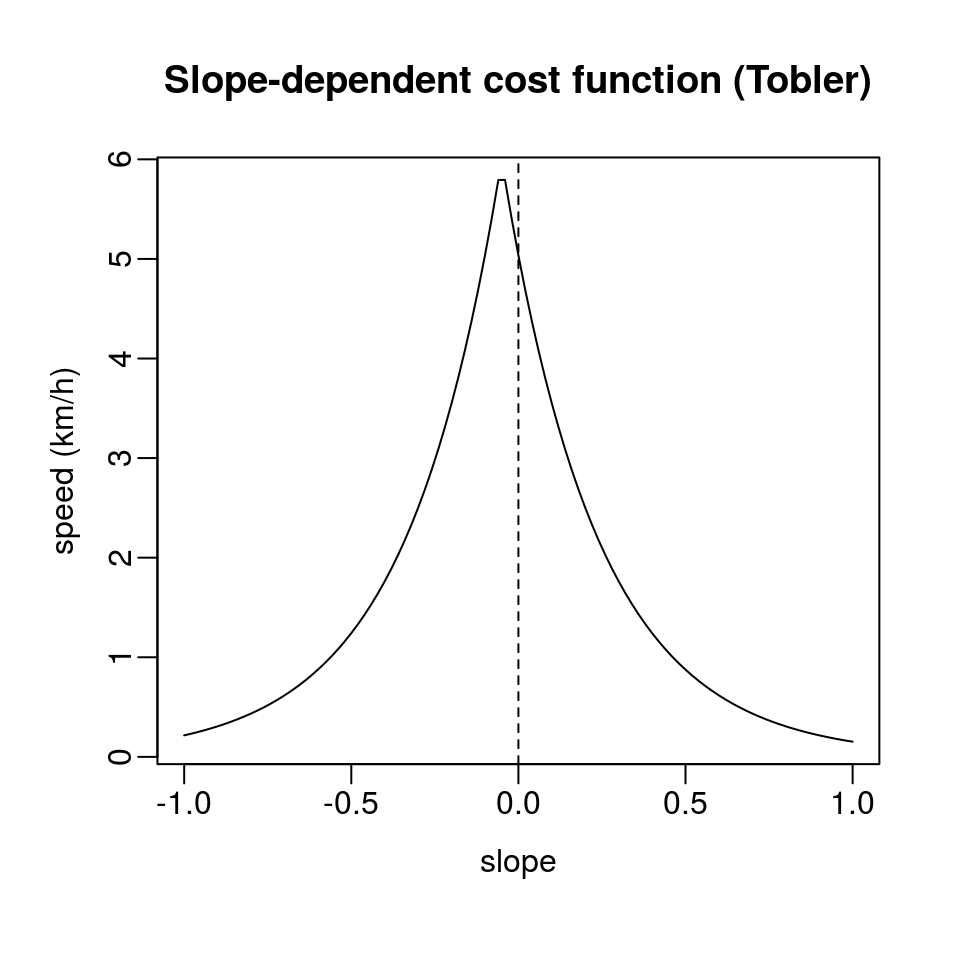

```r
plot(tobler1993a,
     xlim = c(-1,1),
     main = "Slope-dependent cost function (Tobler)",
     xaxt="n",yaxt="n",
     xlab = "",ylab = "")

mtext(side = 1, text = "slope", line = 2)
mtext(side = 2, text = "speed (km/h)", line = 2)

axis(2, mgp=c(3, .5, 0))
axis(1, mgp=c(3, .5, 0))

abline(v = 0, lty = 2)
```

[output not shown]

## Least Cost Distance

We use the `gdistance` package ([link + nice vignette](https://cran.r-project.org/web/packages/gdistance/index.html))

1. Auxilliary function (difference vector = slope)
2. Transitional object (which cells are connected in which direction (4,8,16)?)
3. Geocorrection (because a diagonal path is longer than a horizontal/vertical path)
4. Adjacency matrix (check object, i.e. use only those cells that are adjacent; since matrix values for non-adjacent cells are 0 and division by zero leads to `Inf`)
5. Apply cost function on adjacent cells (cell value = the difference in elevation from one to the other)

## Least Cost Distance

```r
library(raster)
srtm <- raster(x = "results/srtm.tif")
srtm <- aggregate(srtm, fact = 10)

library(gdistance) #
hdiff <- function(x){(x[2]-x[1])}

hd <- transition(srtm,hdiff,8,symm=FALSE)
slope <- geoCorrection(hd,scl=FALSE)
adj <- adjacent(x=srtm, cells=1:ncell(srtm), direction=8)
cost <- slope
cost[adj] <- tobler1993a(slope[adj])
conduct <- geoCorrection(cost, scl=FALSE)
```

## Least Cost Distance

It's about time to calculate the shortest path

```r
tmp1 <- shortestPath(conduct,
                     origin = sites@coords[1,],
                     goal = sites@coords[2,],
                     output="SpatialLines"
                     )

tmp2 <- shortestPath(conduct,
                     origin = sites@coords[2,],
                     goal = sites@coords[1,],
                     output="SpatialLines"
                     )
```

## Least Cost Distance

and plot

```r
plot(srtm,
     main = "Least-cost path\nbased on Tobler's function for walking speed"
     )

lines(tmp1, col = "red")
lines(tmp2, col = "blue")
points(sites@coords[1,], pch = 19, cex = .5)
points(sites@coords[2,], pch = 19, cex = .5)
text(sites@coords[1,1], sites@coords[1,2] - 2500, "1st")
text(sites@coords[2,1], sites@coords[2,2] + 2500, "2nd")

legend("bottom",
       c("1st - 2nd", "2nd - 1st"),
       lty = c(1,1),
       col = c("red", "blue", "black"),
       bty = "n"
       )
```

## Least Cost Distance

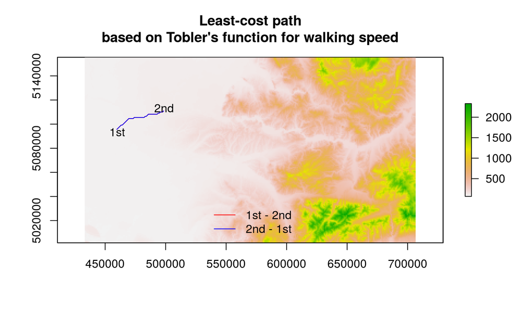

## Least Cost Distance

Let us have a look at the elevation profiles of the calculated paths and compare them to the euclidean path

First, we need to create a spatial line between the 1st and 2nd point

```r
tmp1_euc <- SpatialLines(
    list(
        Lines(
            Line(
                coords = (rbind(sites@coords[1,],
                                sites@coords[2,]
                                )
                )
            ),
            ID="1")
    ),
    proj4string = srtm@crs
)
```

## Least Cost Distance

Let us have a look at the elevation profiles of the calculated paths and compare them to the euclidean path

Now, we can extract the raster values along the spatial lines

```r
p_tmp1_euc <- extract(x=srtm,
                      y=tmp1_euc, along=TRUE
                      )

p_tmp1 <- extract(x=srtm,
                  y=tmp1, along=TRUE
                  )
p_tmp2 <- extract(x=srtm,
                  y=tmp2, along=TRUE
                  )
```

## Least Cost Distance

Let us have a look at the elevation profiles of the calculated paths and compare them to the euclidean path

And now the plot

```r
par(mfrow = c(3,1))
plot(p_tmp1_euc[[1]], type="l",
     main = "Elevation profile \nfrom 1st to 2nd site (euclidean)"
     )
plot(p_tmp1[[1]], type="l",
     main = "Elevation profile \nfrom 1st to 2nd site (least cost)"
     )
plot(p_tmp2[[1]], type="l",
     main = "Elevation profile \nfrom 2nd to 1st site (least cost)"
     )
```

## Least Cost Distance

Let us have a look at the elevation profiles of the calculated paths and compare them to the euclidean path

And now the plot

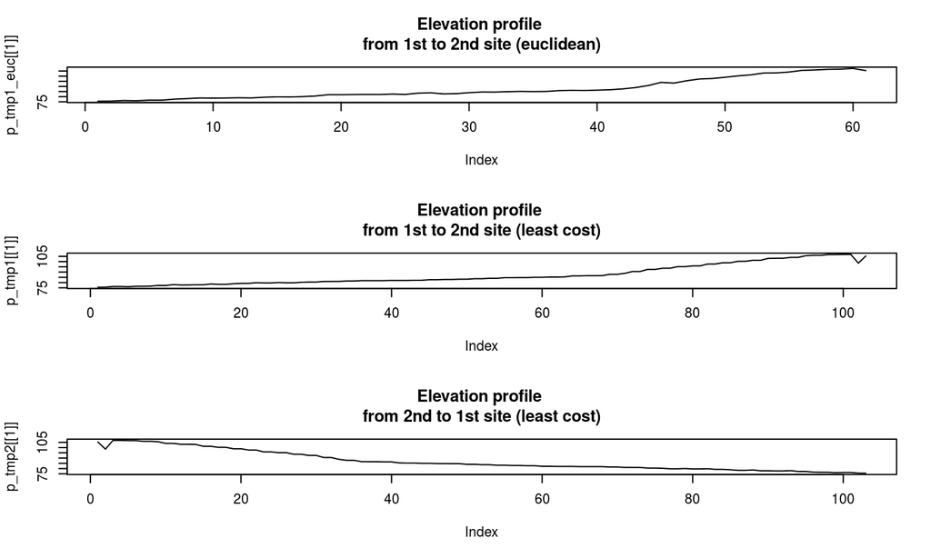

## Least cost paths from all points to all points

First we need a combination object that calculates all the possible connections (and optionally a name object in order to identify the paths afterwards)

```r
x <- sites@coords[,1][1:20] # at the moment only for 20 objects
y <- sites@coords[,2][1:20] # at the moment only for 20 objects

x_comb <- combn(x,2)
y_comb <- combn(y,2)

x_name <- data.frame(sites@data$Nr.[match(x_comb,sites@coords[,1])])
```

## Least cost paths from all points to all points

This will be a rather long loop…

- for all points
- get odd and even numbers for directions, i.e. from odd to even and from even to odd
- select the odd/even coordinates from the combination object and store in variable
- calculate path from odd/even to even/odd
- write an ID to be able to identify the resulting lines
- in the first run of the loop: create the spatial data frame (sdf), i.e. every row is a calculated line
- in the subsequent runs of the loop: append the new lines to the sdf
- in the first run of the loop: create a dataframe (df) with columns "ID", "FROM", "TO"
- in the subsequent runs of the loop: append the new data

## Least cost paths from all points to all points

```r
for(i in 1:(length(x_comb)/2)){
    i1 <- i*2-1 # odd numbers
    i2 <- i*2 # even numbers
    s <- c(x_comb[i1],y_comb[i1])
    z <- c(x_comb[i2],y_comb[i2])
    sz <- shortestPath(conduct, s, z, output="SpatialLines") # calculate the shortest path
    zs <- shortestPath(conduct, z, s, output="SpatialLines") # calculate the shortest path
    sz@lines[[1]]@ID <- as.character(paste(x_name[i1,1],x_name[i2,1]))
    zs@lines[[1]]@ID <- as.character(paste(x_name[i2,1],x_name[i1,1]))

    if(i==1){sdf <-rbind(sz,zs)}
    if(i>1){sdf <- rbind(sdf,sz,zs,
                         makeUniqueIDs = TRUE)
    }

    if(i==1){df <- cbind(ID = c(1,2),
                         FROM = c(paste(x_name[i1,1]),paste(x_name[i2,1])),
                         TO = c(paste(x_name[i2,1]),paste(x_name[i1,1]))
                         )
    }
    if(i>1){df <- cbind(ID = c(df[,1],i1,i2),
                        FROM = c(df[,2],paste(x_name[i1,1]),paste(x_name[i2,1])),
                        TO = c(df[,3],paste(x_name[i2,1]),paste(x_name[i1,1]))
                        )
    }
}
```

## Least cost paths from all points to all points

Create a nice, all integrating SpatialLinesDataFrame object, calculate the length of the lines, and write a shapefile

```r
lcp_df <- as.data.frame(df)
# colnames(lcp_df) <- c("ID","START","TARGET")

lcp_sldf <- SpatialLinesDataFrame(sdf,
                                  lcp_df,
                                  match.ID = FALSE
                                  )

lcp_sldf@data$DIST <- SpatialLinesLengths(lcp_sldf)

writeOGR(lcp_sldf,
         "results/",
         "Least_cost_paths",
         driver = "ESRI Shapefile",
         overwrite_layer = TRUE
         )
```

## and plot

```r
library(magrittr); library(leaflet)

sites_wgs84 <- spTransform(x = sites,
                           CRSobj = "+init=epsg:4326"
                           )
lcp_sldf_wgs84 <- spTransform(x = lcp_sldf,
                              CRSobj = "+init=epsg:4326"
                              )

m1 <- leaflet(lcp_sldf_wgs84) %>%
    addPolylines() %>%
    addProviderTiles("Thunderforest.Landscape") %>%
        addMarkers(lng=sites_wgs84@coords[,1],
                   lat=sites_wgs84@coords[,2],
                   popup = sites@data$Site.Name
                   )
m1
```

[interactive chart not shown]